# Chapter 9- ARIMA

```r
library(fpp3)
```

### [9.1 Stationarity and Differencing](https://otexts.com/fpp3/stationarity.html)

A **stationary time series** is one whose properties do not depend on the time at which the series is observed. More precisely, if $y_t$ is a stationary time series, then for all *s* the distribution of ($y_t$,…,$y_{t+s}$) does not depend on *t*.

A time series can still have cyclical patterns. It’s just that those patterns aren’t a function of *t*.

#### Differencing

**Differencing** is a method of making non-stationary data stationary. Differencing reduces or eliminates trends and seasonality. While transformations and adjustments affect the variance, differencing affects the means.

The differenced y values are a “random walk” model where $y_t$ = $y_{t-1}$ + $\epsilon_t$. Random walks have long periods of up or down and sudden and unpredictible changes in direction. Random walks have naive forecasts. There can also be a *c* in there.

```r
google_2015 <- gafa_stock %>%
  filter(Symbol == "GOOG") %>%
  mutate(day = row_number()) %>%
  update_tsibble(index = day, regular = TRUE) %>%
  filter(year(Date) == 2015)

google_2015 %>%
  mutate(diff_close = difference(Close))
```

| Symbol | Date | Open | High | Low | Close | Adj_Close | Volume | day | diff_close |
| --- | --- | --- | --- | --- | --- | --- | --- | --- | --- |
| GOOG | 2015-01-02 | 526.1147 | 528.3624 | 521.2316 | 521.9377 | 521.9377 | 1447600 | 253 | NA |
| GOOG | 2015-01-05 | 520.3962 | 521.4604 | 510.2520 | 511.0576 | 511.0576 | 2059800 | 254 | -10.880127 |
| GOOG | 2015-01-06 | 512.1815 | 513.3500 | 498.3078 | 499.2128 | 499.2128 | 2899900 | 255 | -11.844818 |
| GOOG | 2015-01-07 | 504.2252 | 504.4679 | 496.9154 | 498.3575 | 498.3575 | 2065100 | 256 | -0.855286 |
| GOOG | 2015-01-08 | 495.2645 | 500.7245 | 488.3128 | 499.9289 | 499.9289 | 3353600 | 257 | 1.571351 |
| GOOG | 2015-01-09 | 501.9975 | 502.1566 | 492.0821 | 493.4545 | 493.4545 | 2069400 | 258 | -6.474366 |
| GOOG | 2015-01-12 | 492.2312 | 493.2616 | 484.8916 | 489.8543 | 489.8543 | 2322400 | 259 | -3.600189 |
| GOOG | 2015-01-13 | 496.1099 | 500.2272 | 489.6952 | 493.4644 | 493.4644 | 2370500 | 260 | 3.610138 |
| GOOG | 2015-01-14 | 491.9428 | 500.4759 | 490.3018 | 498.1288 | 498.1288 | 2235700 | 261 | 4.664337 |
| GOOG | 2015-01-15 | 502.8030 | 502.9124 | 495.0358 | 499.0437 | 499.0437 | 2715800 | 262 | 0.914948 |

[output cut: 242 more lines]

The Ljung-Box Q* statistic can measure the correlation in a series. If P > .05, then the data is considered random.

```r
google_2015 <- google_2015 %>%
  mutate(diff_close = difference(Close))

ljung_box(google_2015$diff_close, lag = 10)
```

```
##   lb_stat lb_pvalue
## 7.9141434 0.6372231
```

If the data does not seem stationary (check an ACF plot) then do second-order differencing. The model would measure the change in the changes. Going beyond second order differencing is rare.

```r
google_2015 %>%
  mutate(second_order_diff = difference(difference(Close)))
```

| Symbol | Date | Open | High | Low | Close | Adj_Close | Volume | day | diff_close | second_order_diff |
| --- | --- | --- | --- | --- | --- | --- | --- | --- | --- | --- |
| GOOG | 2015-01-02 | 526.1147 | 528.3624 | 521.2316 | 521.9377 | 521.9377 | 1447600 | 253 | NA | NA |
| GOOG | 2015-01-05 | 520.3962 | 521.4604 | 510.2520 | 511.0576 | 511.0576 | 2059800 | 254 | -10.880127 | NA |
| GOOG | 2015-01-06 | 512.1815 | 513.3500 | 498.3078 | 499.2128 | 499.2128 | 2899900 | 255 | -11.844818 | -0.964691 |
| GOOG | 2015-01-07 | 504.2252 | 504.4679 | 496.9154 | 498.3575 | 498.3575 | 2065100 | 256 | -0.855286 | 10.989532 |
| GOOG | 2015-01-08 | 495.2645 | 500.7245 | 488.3128 | 499.9289 | 499.9289 | 3353600 | 257 | 1.571351 | 2.426637 |
| GOOG | 2015-01-09 | 501.9975 | 502.1566 | 492.0821 | 493.4545 | 493.4545 | 2069400 | 258 | -6.474366 | -8.045717 |
| GOOG | 2015-01-12 | 492.2312 | 493.2616 | 484.8916 | 489.8543 | 489.8543 | 2322400 | 259 | -3.600189 | 2.874177 |
| GOOG | 2015-01-13 | 496.1099 | 500.2272 | 489.6952 | 493.4644 | 493.4644 | 2370500 | 260 | 3.610138 | 7.210327 |
| GOOG | 2015-01-14 | 491.9428 | 500.4759 | 490.3018 | 498.1288 | 498.1288 | 2235700 | 261 | 4.664337 | 1.054199 |
| GOOG | 2015-01-15 | 502.8030 | 502.9124 | 495.0358 | 499.0437 | 499.0437 | 2715800 | 262 | 0.914948 | -3.749389 |

[output cut: 242 more lines]

#### Seasonal Differencing

Seasonal differencing takes the difference between an observation and the previous observation in the same season. It takes the seasonality out of the data. Seasonal differences are the change between one year to the next.

Sometimes it is necessary to take both first order and seasonal differences. The goal is to get stationary data. Generally, take seasonal differences first because you may not need first order after that.

Note that the seasonal difference comes first and is differenced with a seasonal lag.

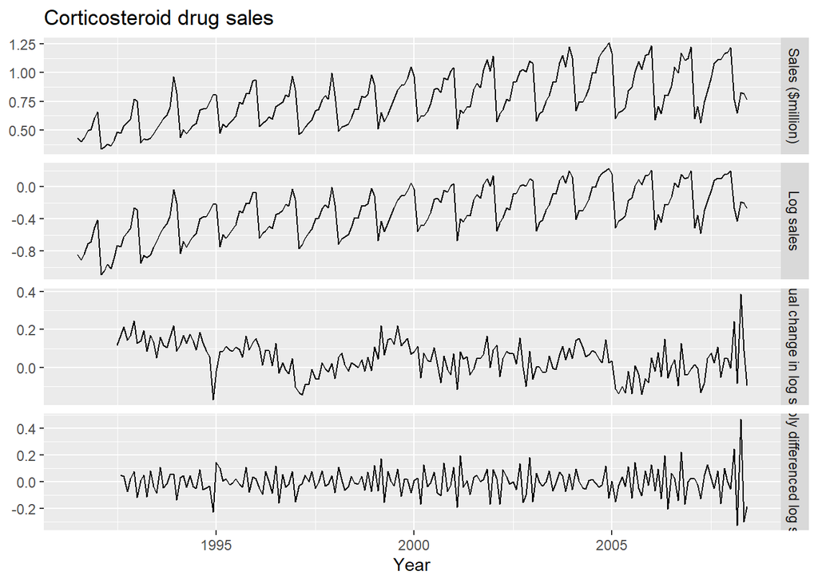

```r
PBS %>%
  filter(ATC2 == "H02") %>%
  summarise(Cost = sum(Cost)/1e6) %>%
  transmute(
    `Sales ($million)` = Cost,
    `Log sales` = log(Cost),
    `Annual change in log sales` = difference(log(Cost), 12),
    `Doubly differenced log sales` = difference(difference(log(Cost), lag = 12), 1)
  ) %>%
  gather("Type", "Sales", !!!syms(measured_vars(.)), factor_key = TRUE) %>%
  ggplot(aes(x = Month, y = Sales)) +
  geom_line() +
  facet_grid(vars(Type), scales = "free_y") +
  labs(title = "Corticosteroid drug sales", x = "Year", y = NULL)
```

#### Unit root tests

Unit root tests will tell you whether differenging is required.

The *KPSS* test tests the null hypothesis that the data is stationary. Use the urca package.

```r
temp <- google_2015 %>%
  mutate(diff_close = difference(Close))
unitroot_kpss(temp$Close)
```

```
##   kpss_stat kpss_pvalue
##    3.560958    0.010000
```

```r
unitroot_kpss(temp$diff_close)
```

```
##   kpss_stat kpss_pvalue
##   0.0988669   0.1000000
```

You can use unitroot_nsdiffs() for the number of seasonal differences and unitroot_ndiffs() for the number of ordered differences. In the example below, one of both is required to achieve stationarity.

```r
aus_total_retail <- aus_retail %>%
  summarise(Turnover = sum(Turnover))

aus_total_retail %>%
  mutate(log_turnover = log(Turnover)) %>%
  features(log_turnover, unitroot_nsdiffs)
```

| nsdiffs |
| --- |
| 1 |

```r
aus_total_retail %>%
  mutate(log_turnover = difference(log(Turnover), 12)) %>%
  features(log_turnover, unitroot_ndiffs)
```

| ndiffs |
| --- |
| 1 |